# Lab Seven: RNN

#### Members:

CSE 5324: Shenxiao Mei

CSE 7324: Chenming Cui, Zeqi Guo

### Introduction

Sarcasm is an ironic remark tempered by humor. Mainly, people use sarcasm to say the opposite of what's true to make someone look or feel foolish. For example, when something bad happens, a person might say "Oh, this is exactly what I need to cheer me up!". This kind of tone is easily identified as a sarcasm by human brains, even though the entire sentence is in absence of an explicit negation marker. Now, human is slow in reading long paper, one might cast a question that can we build a machine that can detect sarcasm for us and make the process quicker?

That's exactly what we are going to do in this lab. We will use a dataset that consists of comments from reddit. The dataset has over one million comments with their parent comment(the context). The dataset is a csv file which consists of two sequence data in the columns of "comment" and "parent_comment".The dataset is balanced and has two labels, 0 for normal comment and 1 sarcastic comment. We will use this dataset to train many-to-one RNN models

### Business Use

Our model for detect sarcastic comment might find its place in an online plagiarism detection application. Currently, the online plagiarism detection scans documents and detect even similarities and generate the list of original sources. With this algorithm, the plagiarism detection can only determine the similarities of words, rather than the sentimental tones. Right now, the detection flags many people's work as plagiarism even though they are simply making sarcastic sentences, which conveys an opposite meaning against the source. Our model can help detect the sarcastic sentences and it can help with improving the plagiarism dectection.

**Source: https://www.kaggle.com/sherinclaudia/sarcastic-comments-on-reddit**  
**Credit to: Mikhail Khodak and Nikunj Saunshi and Kiran Vodrahalli**, who gathered the dataset.

### --Load Data--

First, let us load the dataset. Since our dataset is large we utilize the ManeFrame II to do the work.

```python
import pandas as pd
import numpy as np

df = pd.read_csv('../dataset/train-balanced-sarcasm.csv')
```

```python
df.info()
```

```
<class 'pandas.core.frame.DataFrame'>
RangeIndex: 1010826 entries, 0 to 1010825
Data columns (total 10 columns):
label             1010826 non-null int64
comment           1010773 non-null object
author            1010826 non-null object
subreddit         1010826 non-null object
score             1010826 non-null int64
ups               1010826 non-null int64
downs             1010826 non-null int64
date              1010826 non-null object
created_utc       1010826 non-null object
parent_comment    1010826 non-null object
dtypes: int64(4), object(6)
memory usage: 77.1+ MB
```

```python
df.head()
# https://www.kaggle.com/sherinclaudia/sarcastic-comments-on-reddit
```

|  | label | comment | author | subreddit | score | ups | downs | date | created_utc | parent_comment |
| --- | --- | --- | --- | --- | --- | --- | --- | --- | --- | --- |
| 0 | 0 | NC and NH. | Trumpbart | politics | 2 | -1 | -1 | 2016-10 | 2016-10-16 23:55:23 | Yeah, I get that argument. At this point, I'd ... |
| 1 | 0 | You do know west teams play against west teams... | Shbshb906 | nba | -4 | -1 | -1 | 2016-11 | 2016-11-01 00:24:10 | The blazers and Mavericks (The wests 5 and 6 s... |
| 2 | 0 | They were underdogs earlier today, but since G... | Creepeth | nfl | 3 | 3 | 0 | 2016-09 | 2016-09-22 21:45:37 | They're favored to win. |
| 3 | 0 | This meme isn't funny none of the "new york ni... | icebrotha | BlackPeopleTwitter | -8 | -1 | -1 | 2016-10 | 2016-10-18 21:03:47 | deadass don't kill my buzz |
| 4 | 0 | I could use one of those tools. | cush2push | MaddenUltimateTeam | 6 | -1 | -1 | 2016-12 | 2016-12-30 17:00:13 | Yep can confirm I saw the tool they use for th... |

It looks like we get roughly one million rows and it uses 77MB of memory. That means we probably need to down sample the dataset to train our model after we clean the data

### --Variables--

- label: is the comment sarcastic or not **Binary, Our y Value**
- comment: replay to a parent reddit comment **One of the sequence data**
- author: user ID who post the comment **Nominal,Too many authors, will not use it in training**
- subreddit: comment under which subreddit **Nominal, Categorial, will convert it to integer and add in training**
- subreddit_int: Converted from subreddit
- score: number of upvotes minus number of downvotes **Ordinal**
- ups: number of upvotes **Ordinal, we will not use it because 'score' can represent the total score**
- downs: number of downvotes **Ordinal, we will not use it because 'score' can represent the total score**
- date: commented date **Unrelevant data, will not use it in training**
- created_utc: commented time in the UTC timezone **Unrelevant data, will not use it in training**
- patent_comment: the parent reddit comment to which sarcastic replies are made **One of the sequence data**

Therefore, we will use 'label' as y value, 'comment' and 'parent_comment' as two sequence data, subreddit and score as two another inputs in the RNN

### --Preprocess--

Now, let us preprocess our data. First, we take our any null or NAN data.

```python
if df.isnull().values.any():
    print('exist NULL data')
if(df.isna().values.any()):
    print('exist NaN data')

df = df.dropna(how='any',axis=0)
```

In this part we will define our categorical headers and numeric headers, we will first transform all categorical headers into integers so that our keras model will recognize them as one hotted encoded categorical columns. We will also use the standard scalar to preprocess the numeric data to make all the data centered around 0 and have variance in the same order.  
According to **https://scikit-learn.org/stable/modules/generated/sklearn.preprocessing.StandardScaler.html**, "If a feature has a variance that is orders of magnitude larger that others, it might dominate the objective function and make the estimator unable to learn from other features correctly as expected".Here in our dataset, a few numeric data 'score' is very high and thus becomes "dominating". Therefore, we use the standard scalar to elimniate them.

```python
from sklearn.preprocessing import LabelEncoder
from sklearn.preprocessing import StandardScaler

from keras.layers import Dense, Activation, Input
from keras.layers import Embedding, Flatten, Concatenate
from keras.models import Model

encoders=dict()

categorical_headers=['subreddit']
# print(len(df.groupby(by='author')['subreddit']))

numeric_headers = ["score"]

for col in categorical_headers:
    df[col] = df[col].str.strip()
        # integer encoded variables
    encoders[col] = LabelEncoder() # save the encoder
    df[col+'_int'] = encoders[col].fit_transform(df[col])

# scale the numeric, continuous variables

for col in numeric_headers:
    df[col] = df[col].astype(np.float)

    ss = StandardScaler()
    df[col] = ss.fit_transform(df[col].values.reshape(-1, 1))

df.head()
```

|  | label | comment | author | subreddit | score | ups | downs | date | created_utc | parent_comment | subreddit_int |
| --- | --- | --- | --- | --- | --- | --- | --- | --- | --- | --- | --- |
| 0 | 0 | NC and NH. | Trumpbart | politics | -0.101067 | -1 | -1 | 2016-10 | 2016-10-16 23:55:23 | Yeah, I get that argument. At this point, I'd ... | 12603 |
| 1 | 0 | You do know west teams play against west teams... | Shbshb906 | nba | -0.225177 | -1 | -1 | 2016-11 | 2016-11-01 00:24:10 | The blazers and Mavericks (The wests 5 and 6 s... | 11979 |
| 2 | 0 | They were underdogs earlier today, but since G... | Creepeth | nfl | -0.080382 | 3 | 0 | 2016-09 | 2016-09-22 21:45:37 | They're favored to win. | 12055 |
| 3 | 0 | This meme isn't funny none of the "new york ni... | icebrotha | BlackPeopleTwitter | -0.307918 | -1 | -1 | 2016-10 | 2016-10-18 21:03:47 | deadass don't kill my buzz | 955 |
| 4 | 0 | I could use one of those tools. | cush2push | MaddenUltimateTeam | -0.018327 | -1 | -1 | 2016-12 | 2016-12-30 17:00:13 | Yep can confirm I saw the tool they use for th... | 4234 |

Instead of rewriting df object, we will extract the columns later.

Next, we will find the majority of length of the comments and we will use the length to force a specific length of sequence. We will handle the columns of 'comment' and 'parent comment' separately

```python
import matplotlib.pyplot as plt; plt.rcdefaults()
import numpy as np
import matplotlib.pyplot as plt
```

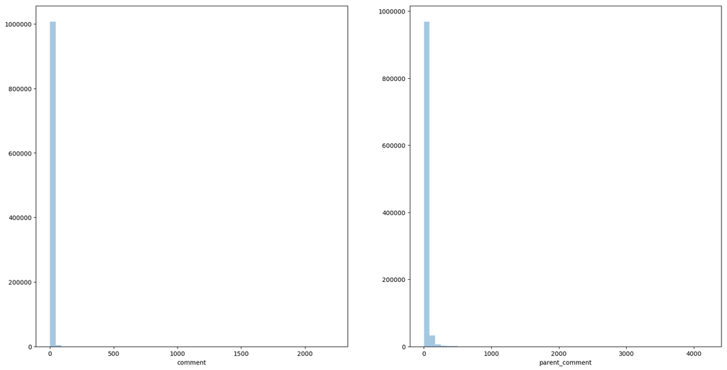

```python
import seaborn as sns
plt.figure(figsize=(20,10))
plt.subplot(1, 2, 1)
sns.distplot(df['comment'].str.split().str.len(), norm_hist=False, kde=False)
plt.subplot(1, 2, 2)
sns.distplot(df['parent_comment'].str.split().str.len(), norm_hist=False, kde=False)
```

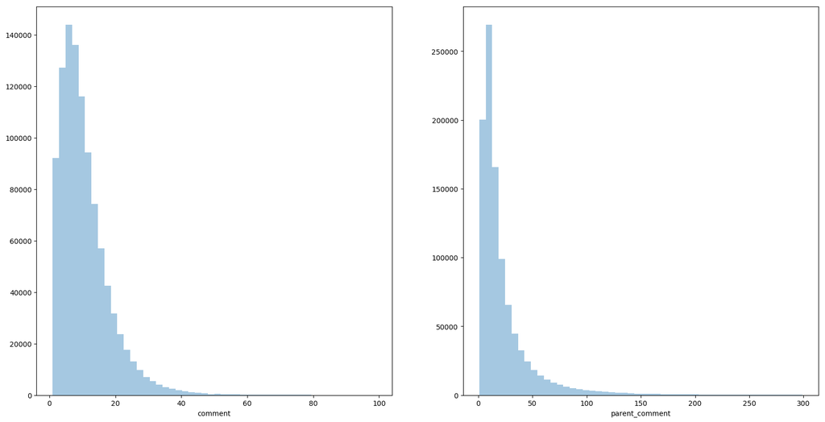

```python
plt.figure(figsize=(20,10))
plt.subplot(1, 2, 1)
sns.distplot(df[df['comment'].str.split().str.len()<100].comment.str.split().str.len(), norm_hist=False, kde=False)
plt.subplot(1, 2, 2)
sns.distplot(df[df['parent_comment'].str.split().str.len()<300].parent_comment.str.split().str.len(), norm_hist=False, kde=False)
```

Looks like we can keep narrowing down.

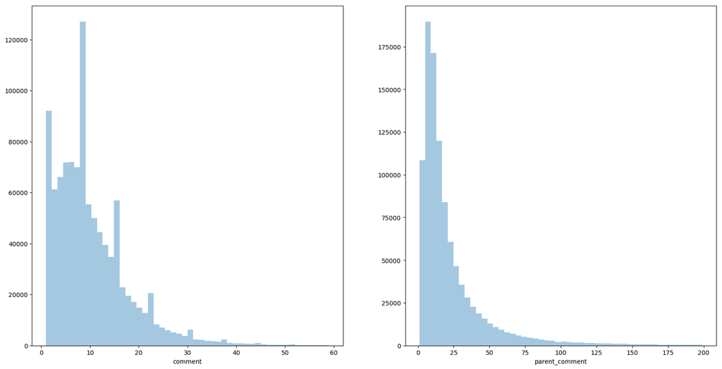

```python
plt.figure(figsize=(20,10))
plt.subplot(1, 2, 1)
sns.distplot(df[df['comment'].str.split().str.len()<60].comment.str.split().str.len(), norm_hist=False, kde=False)
plt.subplot(1, 2, 2)
sns.distplot(df[df['parent_comment'].str.split().str.len()<200].parent_comment.str.split().str.len(), norm_hist=False, kde=False)
```

60 and 200 look like a reasonable size for these two sequences.

```python
df=df[df['comment'].str.split().str.len()<60]
df=df[df['parent_comment'].str.split().str.len()<200]
df.info()
```

```
<class 'pandas.core.frame.DataFrame'>
Int64Index: 1001771 entries, 0 to 1010825
Data columns (total 11 columns):
label             1001771 non-null int64
comment           1001771 non-null object
author            1001771 non-null object
subreddit         1001771 non-null object
score             1001771 non-null float64
ups               1001771 non-null int64
downs             1001771 non-null int64
date              1001771 non-null object
created_utc       1001771 non-null object
parent_comment    1001771 non-null object
subreddit_int     1001771 non-null int64
dtypes: float64(1), int64(4), object(6)
memory usage: 91.7+ MB
```

After the data cleaning we still have over one million rows of data. Looks like it is time to take sample of the dataset. Here we will take 10% of entire dataset with an amount of 100,000 samples.

```python
df = df.sample(frac=0.1)
```

```python
df.groupby('label').size()
```

```
label
0    50203
1    49974
dtype: int64
```

Looks like we still have a balanced dataset, nice!

Since we are using Maneframe II we don't set limit of num_top_word and we will use 60 and 200 as the max length of sequence.

```python
import keras
from keras.preprocessing.text import Tokenizer
from keras.preprocessing.sequence import pad_sequences

NUM_TOP_WORDS = None
MAX_ART_LEN = 60 # maximum and minimum number of words

tokenizer_c = Tokenizer(num_words=NUM_TOP_WORDS)
tokenizer_c.fit_on_texts(df.comment.values)
sequences = tokenizer_c.texts_to_sequences(df.comment.values)

word_index = tokenizer_c.word_index
NUM_TOP_WORDS = len(word_index) if NUM_TOP_WORDS==None else NUM_TOP_WORDS
top_words_comment = min((len(word_index),NUM_TOP_WORDS))
print('Found %s unique tokens. Distilled to %d top words.' % (len(word_index),top_words_comment))

X_comment = pad_sequences(sequences, maxlen=MAX_ART_LEN)

print('Shape of data tensor:', X_comment.shape)
print(X_comment)
```

```
Found 51071 unique tokens. Distilled to 51071 top words.
Shape of data tensor: (100177, 60)
[[    0     0     0 ...     2   776   912]
 [    0     0     0 ...    19   125  8237]
 [    0     0     0 ...    93     2   118]
 ...
 [    0     0     0 ...     1   165  1458]
 [    0     0     0 ...    28   309 14291]
 [    0     0     0 ...    20    86   238]]
```

```python
NUM_TOP_WORDS = None
MAX_ART_LEN = 200 # maximum and minimum number of words

tokenizer_p = Tokenizer(num_words=NUM_TOP_WORDS)
tokenizer_p.fit_on_texts(df.parent_comment.values)
sequences = tokenizer_p.texts_to_sequences(df.parent_comment.values)

word_index = tokenizer_p.word_index
NUM_TOP_WORDS = len(word_index) if NUM_TOP_WORDS==None else NUM_TOP_WORDS
top_words_parent_comment = min((len(word_index),NUM_TOP_WORDS))
print('Found %s unique tokens. Distilled to %d top words.' % (len(word_index),top_words_parent_comment))

X_parent_comment = pad_sequences(sequences, maxlen=MAX_ART_LEN)

print('Shape of data tensor:', X_parent_comment.shape)
print(X_parent_comment)
```

```
Found 72956 unique tokens. Distilled to 72956 top words.
Shape of data tensor: (100177, 200)
[[   0    0    0 ...    5 4800 6914]
 [   0    0    0 ...    5 3217 7376]
 [   0    0    0 ...  811 3218 2118]
 ...
 [   0    0    0 ...   31    1   71]
 [   0    0    0 ... 4684 5872 1560]
 [   0    0    0 ...  181   54  133]]
```

## Divide Data

We have a **large** and **balanced** dataset of 100,000 samples. In this way, we can perform a 80% 20% split because it is very unlikely to find just about 80,000 samples that cannot represent the dataset. Instead of using the train_test_split function, we will use StratifiedShuffleSplit to perform only one split because StratifiedShuffleSplit make sure the proportion of classes are constant in both training data and test data.

```python
from sklearn.model_selection import StratifiedShuffleSplit
sss = StratifiedShuffleSplit(n_splits=1, test_size=0.2, random_state=0)
```

```python
categorical_headers_ints = [x+'_int' for x in categorical_headers]
X_embed=[X_comment,X_parent_comment]
feature_columns = categorical_headers_ints+numeric_headers
X=df[feature_columns].values
X_num=df[numeric_headers].values
X_cat=df[categorical_headers_ints].values
y=df['label']
y=y.values
y_ohe=keras.utils.to_categorical(y, num_classes=2)
```

```python
for train_index, test_index in sss.split(X, y):
#     X_train, X_test = X[train_index], X[test_index]
    X_train_cat, X_test_cat = X_cat[train_index], X_cat[test_index]
    X_train_num, X_test_num = X_num[train_index], X_num[test_index]
    X_train_comment, X_test_comment = X_comment[train_index], X_comment[test_index]
    X_train_parent_comment, X_test_parent_comment = X_parent_comment[train_index], X_parent_comment[test_index]
    y_train, y_test = y[train_index], y[test_index]
    y_train_ohe, y_test_ohe = y_ohe[train_index], y_ohe[test_index]
```

## Metrics

The model return positive if it identifies the sentence is sarcastism and vice versa.

n this lab, we will use Precision as our evaluation metric because we most care about False Positive rate. In our business case, our model is used to detect sarcastism in a plagirism detection. The pain of loss is huge if we identify the work as sarcastic when the work is actually a plagirism. (False Positive). However it is okay for us to miss a few sarcastic comments and flag them as plagirithm. (False Negative). However, we will track the false negative rate and make sure it is not too low.

```python
import keras.backend as K
def precision_m(y_true, y_pred):
        true_positives = K.sum(K.round(K.clip(y_true * y_pred, 0, 1)))
        predicted_positives = K.sum(K.round(K.clip(y_pred, 0, 1)))
        precision = true_positives / (predicted_positives + K.epsilon())
        return precision
```

## Modeling

In this part, we will develop seven RNN models and find their performance to classify the sarcastic comment. Model 1 and Model 2 share most of architecture, the difference is the choice LSTM layer of GRU layer. Model 3 to Model 6 are our attempts to tune the hyperparameters. Model 7 is our attempt to add a second recurrent chain to our model.

We have two sequence embedding layer for 'comment' and 'parent_comment' inputs, one integer input and one categorical embedding layer input, we will first concatenate the sequnce embedding layers and pass to a dense layer to lower down dimension, then we concatenate it with two other inputs, then pass it to dense layers and final output layer.

### --First Architecture--

In first architecture, we will use LSTM with dropout and recurrent_dropout as 0.6 because we want to reduce the chance of overfitting and see if the model can learn more.

```python
from keras.models import Sequential, Input, Model
from keras.layers import Dense, Flatten, concatenate, Dropout
from keras.layers import GRU, LSTM
from keras.layers.embeddings import Embedding


EMBED_SIZE = 50
rnns = []
input_holder_comment = Input(shape=(X_train_comment.shape[1], ))
input_embed_comment = Embedding(top_words_comment, # input dimension (max int of OHE)
                EMBED_SIZE, # output dimension size
                input_length=60)(input_holder_comment) # number of words in each sequence

comment_x = LSTM(60, dropout=0.6, recurrent_dropout=0.6,
                  name='comment_lstm')(input_embed_comment)

input_holder_parent_comment = Input(shape=(X_train_parent_comment.shape[1], ))
input_embed_parent_comment = Embedding(top_words_parent_comment, # input dimension (max int of OHE)
                EMBED_SIZE, # output dimension size
                input_length=200)(input_holder_parent_comment) # number of words in each sequence

parent_comment_x = LSTM(200, dropout=0.6, recurrent_dropout=0.6,
                  name='parent_comment_lstm')(input_embed_parent_comment)


input_numeric=Input(shape=(X_train_num.shape[1],),sparse=False,name='numeric_data')

col='subreddit_int'
N = max(X_train_cat+1)
N=N[0]
input_cat = Input(shape=(1,),dtype='int32', name=col)
cat_x = Embedding(input_dim=N,
                  output_dim=int(np.sqrt(N)),
                  input_length=1, name=col+'_embed')(input_cat)
cat_x = Flatten()(cat_x)

x_2=concatenate([input_numeric,cat_x])
# x_2=Dense(30, activation='relu', name='2_dense')(x_2)

x_1 = concatenate([comment_x,parent_comment_x])
x_1 = Dense(40, activation='relu', name='emb_dense_1')(x_1)
x_1 = Dropout(0.6,seed=2)(x_1)
x_1 = Dense(30, activation='relu', name='emb_dense_2')(x_1)
x_1 = Dropout(0.6,seed=2)(x_1)
x = concatenate([x_2,x_1])

x = Dense(20, activation='relu', name='all_dense_1')(x)
x = Dropout(0.6,seed=2)(x)
x = Dense(10, activation='relu', name='all_dense_2')(x)
x = Dropout(0.6,seed=2)(x)
x = Dense(2, activation='sigmoid', name='outputt')(x)

rnn_1 = Model(inputs=[input_holder_comment,input_holder_parent_comment,input_numeric,input_cat], outputs=x)
```

```python
rnn_1.compile(loss='binary_crossentropy',
              optimizer='rmsprop',
              metrics=[precision_m])
```

```python
history_1=rnn_1.fit([X_train_comment,X_train_parent_comment,X_train_num,X_train_cat],
                    y_train_ohe, epochs=15, batch_size=2000,
                    validation_data=([X_test_comment,X_test_parent_comment,X_test_num,X_test_cat], y_test_ohe))
```

```
Train on 80141 samples, validate on 20036 samples
```

```python
import sklearn.metrics as mt

precision_score_list=[]
precision_score_list.append(mt.precision_score(y_test,yhat_1))

yhat_1 = rnn_1.predict([X_test_comment,X_test_parent_comment,X_test_num,X_test_cat])
yhat_1=np.round(yhat_1)
yhat_1=np.argmax(yhat_1, axis=1)

print(mt.confusion_matrix(y_test,yhat_1),mt.precision_score(y_test,yhat_1))
print('Recall score is: ',mt.recall_score(y_test,yhat_1))
```

[output not shown]

### --Second Architecture--

In this architecture we use GRU instead of LSTM.

```python
from keras.models import Sequential, Input, Model
from keras.layers import Dense, Flatten, concatenate, Dropout
from keras.layers import GRU, LSTM
from keras.layers.embeddings import Embedding


EMBED_SIZE = 50
rnns = []
input_holder_comment = Input(shape=(X_train_comment.shape[1], ))
input_embed_comment = Embedding(top_words_comment, # input dimension (max int of OHE)
                EMBED_SIZE, # output dimension size
                input_length=60)(input_holder_comment) # number of words in each sequence

comment_x = GRU(60, dropout=0.6, recurrent_dropout=0.6,
                  name='comment_lstm')(input_embed_comment)

input_holder_parent_comment = Input(shape=(X_train_parent_comment.shape[1], ))
input_embed_parent_comment = Embedding(top_words_parent_comment, # input dimension (max int of OHE)
                EMBED_SIZE, # output dimension size
                input_length=200)(input_holder_parent_comment) # number of words in each sequence

parent_comment_x = GRU(200, dropout=0.6, recurrent_dropout=0.6,
                  name='parent_comment_lstm')(input_embed_parent_comment)


input_numeric=Input(shape=(X_train_num.shape[1],),sparse=False,name='numeric_data')

col='subreddit_int'
N = max(X_train_cat+1)
N=N[0]
input_cat = Input(shape=(1,),dtype='int32', name=col)
cat_x = Embedding(input_dim=N,
                  output_dim=int(np.sqrt(N)),
                  input_length=1, name=col+'_embed')(input_cat)
cat_x = Flatten()(cat_x)

x_2=concatenate([input_numeric,cat_x])
# x_2=Dense(30, activation='relu', name='2_dense')(x_2)

x_1 = concatenate([comment_x,parent_comment_x])
x_1 = Dense(40, activation='relu', name='emb_dense_1')(x_1)
x_1 = Dropout(0.6,seed=2)(x_1)
x_1 = Dense(30, activation='relu', name='emb_dense_2')(x_1)
x_1 = Dropout(0.6,seed=2)(x_1)
x = concatenate([x_2,x_1])

x = Dense(20, activation='relu', name='all_dense_1')(x)
x = Dropout(0.6,seed=2)(x)
x = Dense(10, activation='relu', name='all_dense_2')(x)
x = Dropout(0.6,seed=2)(x)
x = Dense(2, activation='sigmoid', name='outputt')(x)

rnn_2 = Model(inputs=[input_holder_comment,input_holder_parent_comment,input_numeric,input_cat], outputs=x)
```

```python
rnn_2.compile(loss='binary_crossentropy',
              optimizer='rmsprop',
              metrics=[precision_m])
```

```python
history_2=rnn_2.fit([X_train_comment,X_train_parent_comment,X_train_num,X_train_cat],
                    y_train_ohe, epochs=15, batch_size=2000,
                    validation_data=([X_test_comment,X_test_parent_comment,X_test_num,X_test_cat], y_test_ohe))
```

```
Train on 80141 samples, validate on 20036 samples
```

```python
yhat_2 = rnn_2.predict([X_test_comment,X_test_parent_comment,X_test_num,X_test_cat])
yhat_2=np.round(yhat_2)
yhat_2=np.argmax(yhat_2, axis=1)
precision_score_list.append(mt.precision_score(y_test,yhat_2))
print(mt.confusion_matrix(y_test,yhat_2),mt.precision_score(y_test,yhat_2))
print('Recall score is: ',mt.recall_score(y_test,yhat_2))
```

```
[[7597 2444]
 [4459 5536]] 0.693734335839599
Recall score is:  0.5538769384692346
```

### --Third Architecture--

Tuned hyperparameter: activation function

In this architecture we use LSTM and tune the hyperparameter of activation functions, we will use selu instead of relu

```python
input_holder_comment = Input(shape=(X_train_comment.shape[1], ))
input_embed_comment = Embedding(top_words_comment, # input dimension (max int of OHE)
                EMBED_SIZE, # output dimension size
                input_length=60)(input_holder_comment) # number of words in each sequence

comment_x = LSTM(60, dropout=0.6, recurrent_dropout=0.6,
                  name='comment_lstm')(input_embed_comment)

input_holder_parent_comment = Input(shape=(X_train_parent_comment.shape[1], ))
input_embed_parent_comment = Embedding(top_words_parent_comment, # input dimension (max int of OHE)
                EMBED_SIZE, # output dimension size
                input_length=200)(input_holder_parent_comment) # number of words in each sequence

parent_comment_x = LSTM(200, dropout=0.6, recurrent_dropout=0.6,
                  name='parent_comment_lstm')(input_embed_parent_comment)


input_numeric=Input(shape=(X_train_num.shape[1],),sparse=False,name='numeric_data')

col='subreddit_int'
N = max(X_train_cat+1)
N=N[0]
input_cat = Input(shape=(1,),dtype='int32', name=col)
cat_x = Embedding(input_dim=N,
                  output_dim=int(np.sqrt(N)),
                  input_length=1, name=col+'_embed')(input_cat)
cat_x = Flatten()(cat_x)

x_2=concatenate([input_numeric,cat_x])
# x_2=Dense(30, activation='selu', name='2_dense')(x_2)

x_1 = concatenate([comment_x,parent_comment_x])
x_1 = Dense(40, activation='selu', name='emb_dense_1')(x_1)
x_1 = Dropout(0.6,seed=2)(x_1)
x_1 = Dense(30, activation='selu', name='emb_dense_2')(x_1)
x_1 = Dropout(0.6,seed=2)(x_1)
x = concatenate([x_2,x_1])

x = Dense(20, activation='selu', name='all_dense_1')(x)
x = Dropout(0.6,seed=2)(x)
x = Dense(10, activation='selu', name='all_dense_2')(x)
x = Dropout(0.6,seed=2)(x)
x = Dense(2, activation='sigmoid', name='outputt')(x)

rnn_3 = Model(inputs=[input_holder_comment,input_holder_parent_comment,input_numeric,input_cat], outputs=x)
```

```python
rnn_3.compile(loss='binary_crossentropy',
              optimizer='rmsprop',
              metrics=[precision_m])
```

```python
history_3=rnn_3.fit([X_train_comment,X_train_parent_comment,X_train_num,X_train_cat],
                    y_train_ohe, epochs=10, batch_size=2000,
                    validation_data=([X_test_comment,X_test_parent_comment,X_test_num,X_test_cat], y_test_ohe))
```

```
Train on 80141 samples, validate on 20036 samples
```

```python
yhat_3 = rnn_3.predict([X_test_comment,X_test_parent_comment,X_test_num,X_test_cat])
yhat_3=np.round(yhat_3)
yhat_3=np.argmax(yhat_3, axis=1)
precision_score_list.append(mt.precision_score(y_test,yhat_3))
print(mt.confusion_matrix(y_test,yhat_3),mt.precision_score(y_test,yhat_3))
print('Recall score is: ',mt.recall_score(y_test,yhat_3))
```

```
[[5905 4136]
 [2816 7179]] 0.6344675209898365
Recall score is:  0.7182591295647824
```